# Ethereum Project

This project will utilize Jupyter notebooks and CoinMarketCap API documentation in order to retreive current data on Ethereum.

### Getting Started: Setup Session and Send GET Request

```python
#import requests needed to retrieve session,send API requests, and organize data.
from requests import Request, Session
import json
import pprint

url = " https://pro-api.coinmarketcap.com/v2/cryptocurrency/quotes/latest"
cryptocurrency = {'slug':'ethereum', 'convert':'USD' }

#Accept Json response
headers = { 'Accepts':'application/json','X-CMC_PRO_API_KEY':'c9f0fe76-623a-4d5c-a08f-3f60cb29f510'}

session = Session()
session.headers.update(headers)
#Send GET request
response = session.get(url, params=cryptocurrency)

print(response.text)
```

```
{"status":{"timestamp":"2024-01-23T19:29:56.919Z","error_code":0,"error_message":null,"elapsed":98,"credit_count":1,"notice":null},"data":{"1027":{"id":1027,"name":"Ethereum","symbol":"ETH","slug":"ethereum","num_market_pairs":8323,"date_added":"2015-08-07T00:00:00.000Z","tags":[{"slug":"pos","name"…
```

### Organizing Data

In order to make writing code easier for the next steps we will organize the data via pprint. Pprint is a python library that will automatically print data structures in an organized way.

```python
pprint.pprint(json.loads(response.text))
```

```
{'data': {'1027': {'circulating_supply': 120178316.75993022,
                   'cmc_rank': 2,
                   'date_added': '2015-08-07T00:00:00.000Z',
                   'id': 1027,
                   'infinite_supply': True,
                   'is_active': 1,
                   'is_fiat': 0,
                   'last_updated': '2024-01-23T18:58:00.000Z',
                   'max_supply': None,
                   'name': 'Ethereum',
                   'num_market_pairs': 8322,
                   'platform': None,
                   'quote': {'USD': {'fully_diluted_market_cap': 263513976809.42,
                                     'last_updated': '2024-01-23T18:58:00.000Z',
                                     'market_cap': 263513976809.41873,
                                     'market_cap_dominance': 17.2608,
                                     'percent_change_1h': -0.70138159,
                                     'percent_change_24h': -7.48819931,
                                     'percent_change_30d': -4.33085641,
                                     'percent_change_60d': 4.83869904,
                                     'percent_change_7d': -14.33977117,
                                     'percent_change_90d': 22.32357193,
                                     'price': 2192.6915263409596,
                                     'tvl': None,
                                     'volume_24h': 16941416766.008026,
                                     'volume_change_24h': 49.2278}},
                   'self_reported_circulating_supply': None,
                   'self_reported_market_cap': None,
                   'slug': 'ethereum',
                   'symbol': 'ETH',
                   'tags': [{'category': 'ALGORITHM',
                             'name': 'PoS',
                             'slug': 'pos'},
                            {'category': 'CATEGORY',
                             'name': 'Smart Contracts',
                             'slug': 'smart-contracts'},
                            {'category': 'PLATFORM',
                             'name': 'Ethereum Ecosystem',
                             'slug': 'ethereum-ecosystem'},
                            {'category': 'CATEGORY',
```

[output cut: 73 more lines]

```
                             'slug': 'injective-ecosystem'},
                            {'category': 'CATEGORY',
                             'name': 'Layer 1',
                             'slug': 'layer-1'},
                            {'category': 'CATEGORY',
                             'name': 'FTX Bankruptcy Estate ',
                             'slug': 'ftx-bankruptcy-estate'}],
                   'total_supply': 120178316.75993022,
                   'tvl_ratio': None}},
 'status': {'credit_count': 1,
            'elapsed': 16,
            'error_code': 0,
            'error_message': None,
            'notice': None,
            'timestamp': '2024-01-23T18:58:55.413Z'}}
```

# Retreiving Data

Now that we have the data in a readable format we will retreive what we need. In this case we see that price and market cap are nested inside the following: data, 1027, quote, and USD. Before we retrieve these 2 values we will need to access this part of the json response.

Once we set the values of price and marketcap we will return these values in currency format.

```python
#Accessing data and assigning price and marketcap variables
price = json.loads(response.text)['data']['1027']['quote']['USD']['price']
marketcap = json.loads(response.text)['data']['1027']['quote']['USD']['market_cap']

print('The market cap of Etherum is currently: ' + '${:,.2f}'.format(marketcap))
print('The price of Etherum is currently: ' + '${:,.2f}'.format(price))
```

```
The market cap of Etherum is currently: $262,923,685,446.18
The price of Etherum is currently: $2,187.78
```

# Bonus: Investment Calculator

This is a bonus section where I use matplotlib to graph the compounding effect of an investment. Here are the following variables in this example:

Balance = 1000 Rate = 10% Years compounded = 5

I've taken an approximation of the S&P 500 fund annual gains (currently averaging around 10%) and am simulating growth with a beginning balance of $1000.

```
The balance for year 1: $1,100.00
The balance for year 2: $1,210.00
The balance for year 3: $1,331.00
The balance for year 4: $1,464.10
The balance for year 5: $1,610.51
```

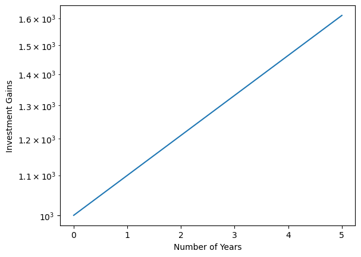

```python
#import matplotlib and assign value. This library is responsible for graphing the data
import matplotlib.pyplot as plt

#This function will return a list of yearly compounded balances at an assigned rate.
def compound_by_period(balance, rate, num_periods):
    """
    Returns a list of balances based on initial balance, rate, and number of periods.

    balance: Initial investment
    rate: Percentage rate
    num_years: Amount of years compounded
    """
    balances = [balance]
    for n in range(1,num_periods+1):
        balance = round( balance * (1 + rate), 2)
        balances.append(balance)
        print('The balance for year ' + str(n) + ': ' + '${:,.2f}'.format(balance))
    return balances

investment = compound_by_period(1000,.10,5)
# Plot graph
plt.semilogy(investment)
plt.xlabel('Number of Years')
plt.ylabel('Investment Gains')
```